# Chapter 2

## Regression and model validation

Link to IODS repository: https://github.com/dawit2010/IODS-project

In this chapter, we have looked at building and validating regression models using R. Specifically, we built a simple linear regression model which assumes linear relationship between a target variable of interest and other variables. Thus allowing prediction of the values of the target variable based on information from other variables.

The data we use for this analysis is [JYTOPKYS3](http://www.helsinki.fi/~kvehkala/JYTmooc/JYTOPKYS3-meta.txt). It is an international survey of approaches to statistical learning.

#### Data wrangling

We first preprocessed the raw data found [here](http://www.helsinki.fi/~kvehkala/JYTmooc/JYTOPKYS3-data.txt) by combining existing variables and creating new variables. The script used for data wrangling and the preprocessed analysis ready dataset are available in the directory named data in the [git repository](https://github.com/Dawit2010/IODS-project). The details of how this is done including the R commands used can be found [here](https://github.com/Dawit2010/IODS-project/blob/master/data/create_learning2014.R). The analysis dataset after this data wrangling step ready for further analysis can be found [here](https://github.com/Dawit2010/IODS-project/blob/master/data/learning2014.txt)

#### Regression analysis

- Reading in data

We read in the analysis ready dataset that we prepared (as described above):

```r
ldata <- read.table("data/learning2014.txt",header=T, sep="\t")
```

and explore the structure and dimention of the dataset.The dimension can also be using the dim function.

```r
str(ldata)
```

```
## 'data.frame':    166 obs. of  7 variables:
##  $ gender  : Factor w/ 2 levels "F","M": 1 2 1 2 2 1 2 1 2 1 ...
##  $ Age     : int  53 55 49 53 49 38 50 37 37 42 ...
##  $ attitude: num  3.7 3.1 2.5 3.5 3.7 3.8 3.5 2.9 3.8 2.1 ...
##  $ deep    : num  3.58 2.92 3.5 3.5 3.67 ...
##  $ stra    : num  3.38 2.75 3.62 3.12 3.62 ...
##  $ surf    : num  2.58 3.17 2.25 2.25 2.83 ...
##  $ Points  : int  25 12 24 10 22 21 21 31 24 26 ...
```

```r
dim(ldata)
```

```
## [1] 166   7
```

The dataset contains 166 observations with 7 variables. Variables deep,stra,and surf are combined variables that were prepared in the data wrangling step. The data has information on student exam points along with gender, age, attitude, and three general methods of learning approaches measuring aspects of learning termed as deep, strategy and surface.

- Overview of data

Let’s look at the top 6 observations in the dataset

```r
head(ldata)
```

```
##   gender Age attitude     deep  stra     surf Points
## 1      F  53      3.7 3.583333 3.375 2.583333     25
## 2      M  55      3.1 2.916667 2.750 3.166667     12
## 3      F  49      2.5 3.500000 3.625 2.250000     24
## 4      M  53      3.5 3.500000 3.125 2.250000     10
## 5      M  49      3.7 3.666667 3.625 2.833333     22
## 6      F  38      3.8 4.750000 3.625 2.416667     21
```

We can have a simple summary of each variable. We can see the number of Female and male responders in the dataset. We can also observe the mean values for age, attitude, deep, stra, surf and exam points.

```r
summary(ldata)
```

```
##  gender       Age           attitude          deep            stra
##  F:110   Min.   :17.00   Min.   :1.400   Min.   :1.583   Min.   :1.250
##  M: 56   1st Qu.:21.00   1st Qu.:2.600   1st Qu.:3.333   1st Qu.:2.625
##          Median :22.00   Median :3.200   Median :3.667   Median :3.188
##          Mean   :25.51   Mean   :3.143   Mean   :3.680   Mean   :3.121
##          3rd Qu.:27.00   3rd Qu.:3.700   3rd Qu.:4.083   3rd Qu.:3.625
##          Max.   :55.00   Max.   :5.000   Max.   :4.917   Max.   :5.000
##       surf           Points
##  Min.   :1.583   Min.   : 7.00
##  1st Qu.:2.417   1st Qu.:19.00
##  Median :2.833   Median :23.00
##  Mean   :2.787   Mean   :22.72
##  3rd Qu.:3.167   3rd Qu.:27.75
##  Max.   :4.333   Max.   :33.00
```

It would be interesting to explore the relationship between variables. A nice function to do this is ggpairs of the package GGally that we learned from our datacamp exercise.

```r
library(GGally)
```

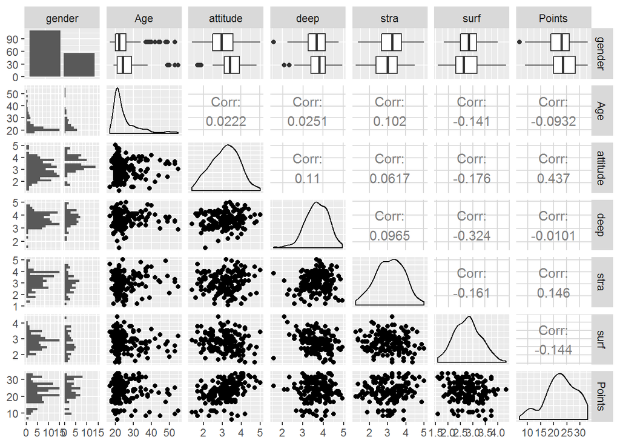

```r
library(ggplot2)
# create a more advanced plot matrix with ggpairs()
p <- ggpairs(ldata, mapping = aes(), lower = list(combo = wrap("facethist", bins = 20)))
p
```

ggpairs plots the relationsship between all possible pairs of variables in the dataset. The distribution of each variable indicated, with most being normal while age, deep and points are skewed. Since we are interesed in the relationship of other variables to exam points, we can look closely their correlation to to Points. We collect all absolute correlation coefficent of the other variables to exam points, and sort them from highest to lowest. The variables are now ordered from most correlated to least correlated to exam points to help us choose variables for the regression analysis.

```r
corToPoints <- cor(ldata[-1])
corToPoints
```

```
##                  Age    attitude        deep        stra       surf
## Age       1.00000000  0.02220071  0.02507804  0.10244409 -0.1414052
## attitude  0.02220071  1.00000000  0.11024302  0.06174177 -0.1755422
## deep      0.02507804  0.11024302  1.00000000  0.09650255 -0.3238020
## stra      0.10244409  0.06174177  0.09650255  1.00000000 -0.1609729
## surf     -0.14140516 -0.17554218 -0.32380198 -0.16097287  1.0000000
## Points   -0.09319032  0.43652453 -0.01014849  0.14612247 -0.1443564
##               Points
## Age      -0.09319032
## attitude  0.43652453
## deep     -0.01014849
## stra      0.14612247
## surf     -0.14435642
## Points    1.00000000
```

```r
sort(abs(corToPoints[,6][-6]),decreasing=T)
```

```
##   attitude       stra       surf        Age       deep
## 0.43652453 0.14612247 0.14435642 0.09319032 0.01014849
```

- Fitting a regression model